# Statistical Inference Project One - Simulation

Tianxiang Liu

Sunday, September 07, 2014

The exponential distribution can be simulated in R with rexp(n, lambda) where lambda is the rate parameter. The mean of exponential distribution is 1/lambda and the standard deviation is also also 1/lambda. Set lambda = 0.2 for all of the simulations. In this simulation, we will investigate the distribution of averages of 40 exponential(0.2)s. Note that we will need to do a thousand or so simulated averages of 40 exponentials.

```r
# Setup and run the simulation
setwd('C:\\Users\\Ivan.Liuyanfeng\\Desktop\\Data_Mining_Work_Space\\Data-Science-Statistical-Inference\\project')
library(ggplot2)
lambda <- 0.2
n <- 40
itr <- 1000
set.seed(1234)
sim <- replicate(itr, rexp(n,lambda))
```

### Section One

Show where the distribution is centered at and compare it to the theoretical center of the distribution.

```r
sim.mean <- sapply(1:itr, function(i) mean(sim[,i]))
# Calculated mean and theoretical mean
s1 <- data.frame('mean'=c(mean(sim.mean),1/lambda), row.names=c('calculated','theoretical'))
s1
```

```
##              mean
## calculated  4.974
## theoretical 5.000
```

### Section Two

Show how variable it is and compare it to the theoretical variance of the distribution.

```r
sim.sd <- sd(as.vector(sim.mean))
sim.var <- var(as.vector(sim.mean))
theo.sd <- (1/lambda * 1/sqrt(n))
theo.var <- theo.sd ^ 2
# Calculated sd, var and theoretical sd, var
s2 <- data.frame('sd'=c(sim.sd, theo.sd), 'var'=c(sim.var,theo.var), row.names=c('calculated','theoretical'))
s2
```

```
##                 sd    var
## calculated  0.7554 0.5707
## theoretical 0.7906 0.6250
```

### Section Three

Show that the distribution is approximately normal.

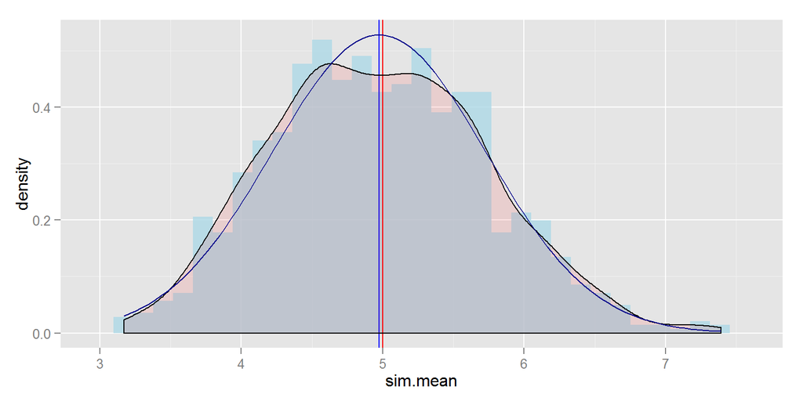

```r
# Density Plot
sim.mean <- as.data.frame(sim.mean)
g <- ggplot(sim.mean,aes(x=sim.mean))
g + geom_histogram(aes(y = ..density..),fill='lightblue',alpha=.8) +
    geom_vline(data=s1, aes(xintercept=mean), color=c('blue','red')) +
    geom_density(alpha=.1, fill='red') +
    stat_function(fun=dnorm, args=list(mean=mean(sim.mean[,1]), sd=sim.sd),color = "darkblue")
```

We can see the shape of density plot of simulation is almost identical to the shape of normal distribution (which is dark blue line in the diagram).

### Section Four

```r
coverage <- data.frame('Low'=NA,'High'=NA)
for(i in 1:itr){
    coverage[i,]<- mean(sim[,i])+c(-1.96,1.96)*sd(sim[,i])/sqrt(n)
    }
head(coverage,n=5)
```

```
##     Low  High
## 1 3.389 6.549
## 2 4.207 7.290
## 3 2.447 4.184
## 4 4.335 8.496
## 5 3.519 5.812
```

```r
Coverage <- nrow(coverage[which(coverage$Low < 5 & coverage$High > 5),])/itr
# Coverage of the confidence interval for 1/lambda is:
Coverage
```

```
## [1] 0.932
```

**Thank you for reading!** **Ivan Liu** **07/09/2014**